# Diving Logbook Overview

Ruben Perez Perez

2021-04-05

This document provides a thorough visualization and exploration of a SCUBA Diving Logbook through the usage of spatio-temporal and categorical plots and maps and informative data tables. *Please note that some plots may seem incomplete. This is due to the lack of high quality data in the logbook, e.g. maximumDepthInMeters, locationID and bottomTime were not recorded for all the dives.*

## Maps and plots

### Dives distribution map

This is an interactive map with detailed information on each dive (*feel free to click and hover over the dive points to find more information about each dive*):

[interactive chart not shown]

### Number of dive types

This barplot shows the number of dives per dive type and class. It reflects the diving experience of the diver regarding performance and type of training.

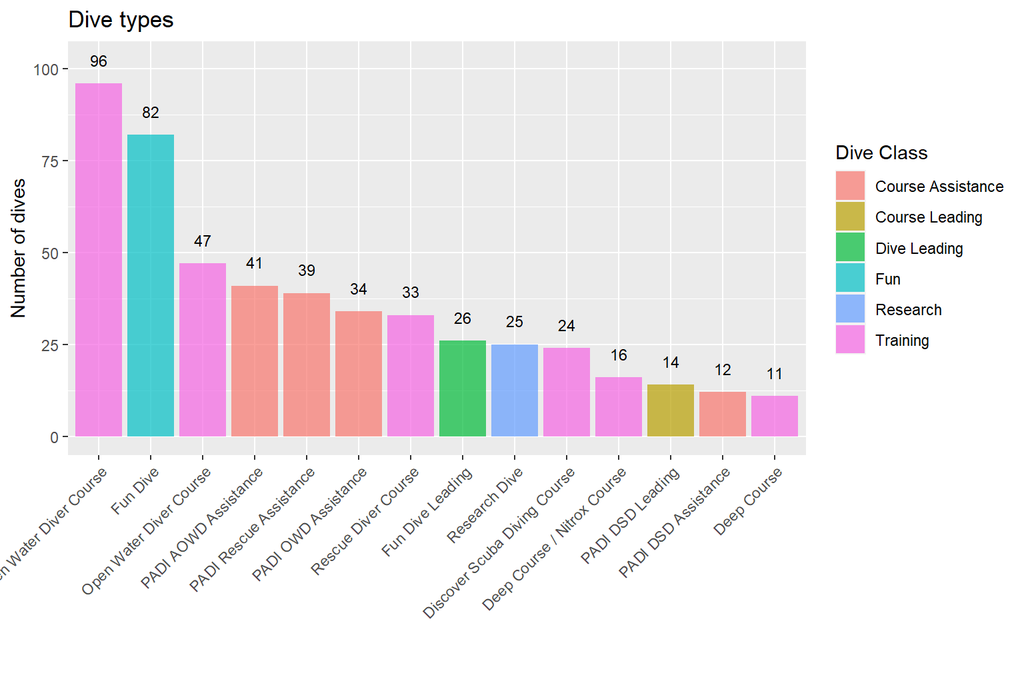

### Cumulative number of dives

This plot shows the cumulative number of dives over time. It reflects the overall diving experience of the diver.

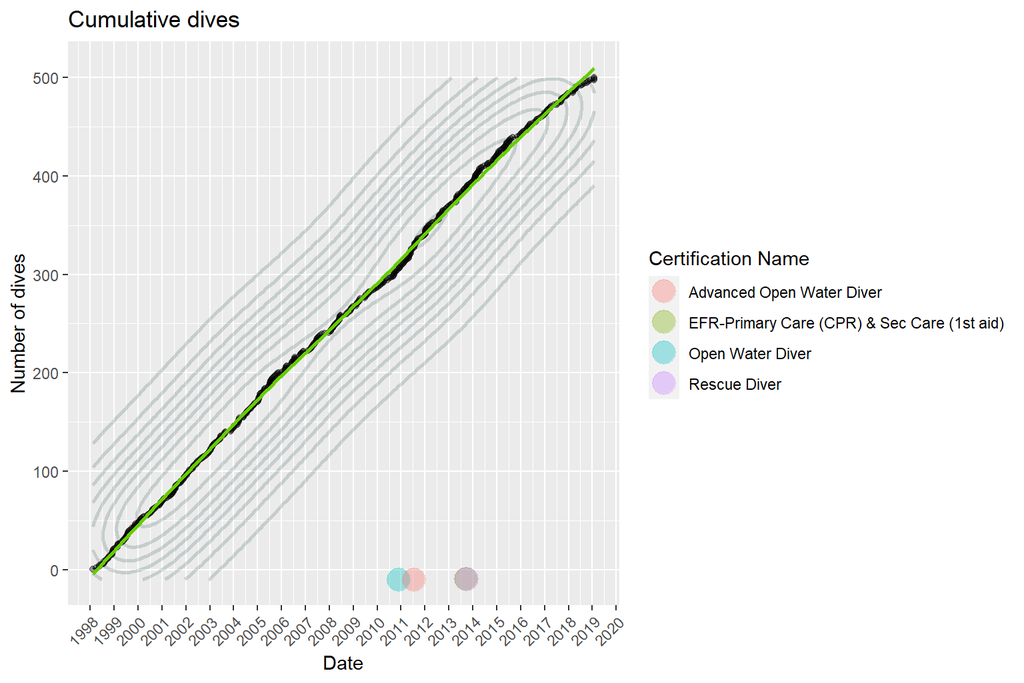

### Logged dives depths

This scatterplot shows the maximum depths of a number of dives over time. It reflects the experience of the diver regarding depth.

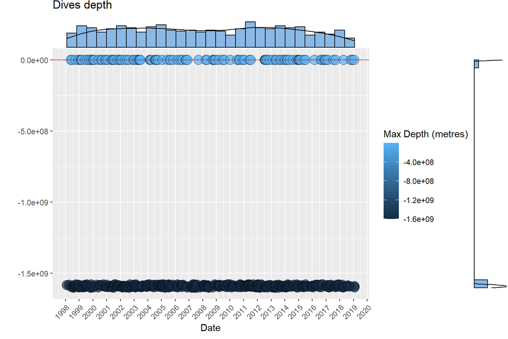

### Dives per country and region

This barplot shows the number of dives per region and country. It reflects the experience of the diver regarding variety of divesites.

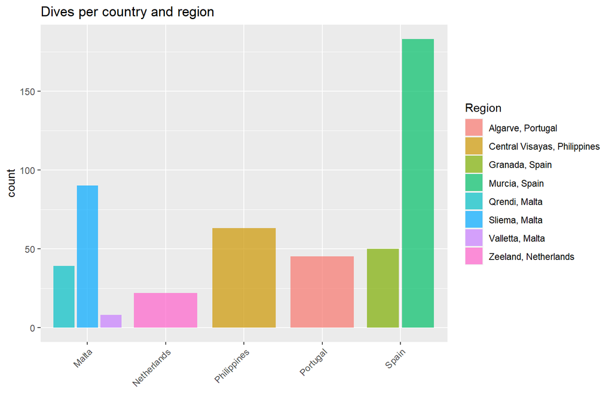

### Dive sites depths variation

This boxplot shows the maximum depth variation of each divesite according to the data collected from this logbook. This plot can be helpful for planning dives or trainings with specific depth requirements.

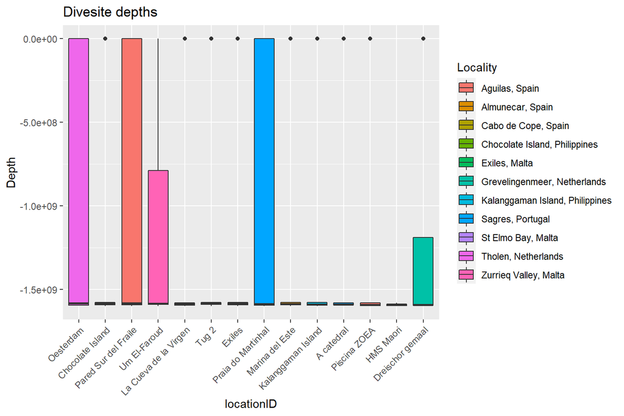

### Platform type dives

This barplot shows the number of dives per platform and region/country (boat, shore, pool). This plot gives a glimpse of the experience of the diver regarding the entrance to the water.

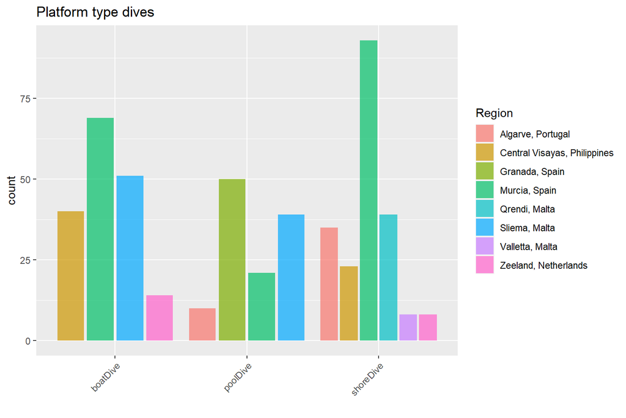

## Data

### Highlights

This data frame shows some highlights extracted from the diving logbook. Please take into account that not all the data (such as dates, depths or bottom times) are always recorded for every dive.

| Recorded | Value |
| --- | --- |
| Number of dives | 500 |
| Number of dive sites | 14 dive sites (5 countries) |
| Maximum depth | 1601424000 meters |
| Total bottom time | 310 hours (500 bottom times recorded) |
| Maximum bottom time in a dive | 50 minutes |
| Diving since | 22 years ago |
| Last dive | 2019-12-29 = 463 days ago |

### Logbook data

This data frame shows the diving logbook used. Personal information such as eventRemarks are omitted from this data frame

| eventDate | locationID | locality | maximumDepth | bottomTime | diveType | diveClass | platformType | region | country |
| --- | --- | --- | --- | --- | --- | --- | --- | --- | --- |
| 1999-01-10 | Praia do Martinhal | Sagres | 1584748800 | 36 | Fun Dive | Fun | shoreDive | Algarve | Portugal |
| 1999-03-04 | Exiles | Exiles | 1580947200 | 42 | Open Water Diver Course | Training | poolDive | Sliema | Malta |
| 1999-04-19 | Um El-Faroud | Zurrieq Valley | 1595116800 | 48 | Advanced Open Water Diver Course | Training | shoreDive | Qrendi | Malta |
| 1999-04-21 | Exiles | Exiles | 20 | 46 | Discover Scuba Diving Course | Training | poolDive | Sliema | Malta |
| 1999-05-23 | Pared Sur del Fraile | Aguilas | 35.7 | 39 | Advanced Open Water Diver Course | Training | shoreDive | Murcia | Spain |
| 1999-06-21 | Marina del Este | Almunecar | 1586390400 | 34 | Rescue Diver Course | Training | poolDive | Granada | Spain |
| 1999-06-30 | Tug 2 | Exiles | 1601164800 | 42 | PADI OWD Assistance | Course Assistance | boatDive | Sliema | Malta |
| 1999-07-05 | La Cueva de la Virgen | Cabo de Cope | 1598400000 | 45 | PADI OWD Assistance | Course Assistance | boatDive | Murcia | Spain |
| 1999-07-25 | Kalanggaman Island | Kalanggaman Island | 1593043200 | 30 | Deep Course / Nitrox Course | Training | boatDive | Central Visayas | Philippines |
| 1999-08-05 | A catedral | Sagres | 1594425600 | 41 | Advanced Open Water Diver Course | Training | poolDive | Algarve | Portugal |

[output cut: 490 more lines]

## Certifications

| diverID | certificationName | certificationAgency | certificationDate |
| --- | --- | --- | --- |
| XXXXX | Open Water Diver | PADI | 2011-10-23 |
| XXXXX | Advanced Open Water Diver | PADI | 2012-06-17 |
| XXXXX | EFR-Primary Care (CPR) & Sec Care (1st aid) | PADI | 2014-08-24 |
| XXXXX | Rescue Diver | PADI | 2014-08-27 |